# LMM analyses TeenLight

Author

R Lazar

Published

May 22, 2025

# Preparing the environment

## Loading the Libraries

```r
# Install and load pacman if not already installed
if (!require("pacman")) install.packages("pacman")

# Load all the packages using pacman
pacman::p_load(
  #for LMM
  lme4,
  lmerTest,
  sjPlot,
  lqmm,

  # for repeated measure correlation
  rmcorr,

  # for general data wrangling
  DescTools,
  lubridate,
  tidyverse,

  qqplotr,    # For QQ plots in linear assumptions check
  performance, # For linear assumptions check
  see,        # For linear assumptions check
  rmarkdown,   # For reproducible reporting
  here# for loading data easily
)
```

# Melatonin analysis

## Evening melatonin AUC (primary outcome)

- Here we use the evening AUC computed with the trapedzoid method.
- n=20 (2 participants excluded)

### Defining LMMs:

- covariate model (additionally including bright light history, pubertal stage and chronotype)

```r
AUC_mel_eve <- lmer(
formula =  auc_mel_eve ~ Block + D1_TAT1k  + mctq_sc4_chronotype + pub_stage + (1 |record_id),
                data = Mel_summary)
```

- sparse model

```r
AUC_mel_eve_sparse <- lmer(
formula =  auc_mel_eve ~ Block + (1 | record_id),
                data = Mel_summary)
```

### Compute LMM results for covariate model (relative to “dim” condition)

```r
summary(AUC_mel_eve)
```

```
Linear mixed model fit by REML. t-tests use Satterthwaite's method [
lmerModLmerTest]
Formula: auc_mel_eve ~ Block + D1_TAT1k + mctq_sc4_chronotype + pub_stage +
    (1 | record_id)
   Data: Mel_summary

REML criterion at convergence: 510.4

Scaled residuals:
     Min       1Q   Median       3Q      Max
-1.83786 -0.46187 -0.03226  0.40920  2.32564

Random effects:
 Groups    Name        Variance Std.Dev.
 record_id (Intercept) 4623.5   68.00
 Residual               207.5   14.41
Number of obs: 60, groups:  record_id, 20

Fixed effects:
                        Estimate Std. Error      df t value Pr(>|t|)
(Intercept)              179.053     88.922  14.682   2.014  0.06276 .
Blockmoderate             -7.372      4.558  36.636  -1.617  0.11439
Blockbright              -11.292      4.603  36.754  -2.453  0.01903 *
D1_TAT1k                   5.647      2.072  42.744   2.725  0.00927 **
mctq_sc4_chronotype      -30.618     20.409  14.490  -1.500  0.15503
pub_stageLate pubertal    38.748     38.337  14.533   1.011  0.32869
pub_stageMidpubertal     -21.372     43.415  14.476  -0.492  0.62991
pub_stageEarly pubertal   20.797     76.939  14.576   0.270  0.79072
---
Signif. codes:  0 '***' 0.001 '**' 0.01 '*' 0.05 '.' 0.1 ' ' 1

Correlation of Fixed Effects:
            (Intr) Blckmd Blckbr D1_TAT mct_4_ pb_sLp pb_stM
Blockmodert -0.028
Blockbright -0.037  0.500
D1_TAT1k    -0.082  0.035  0.143
mctq_sc4_ch -0.936  0.001  0.003  0.023
pb_stgLtpbr -0.342  0.002  0.007  0.046  0.069
pb_stgMdpbr -0.303  0.000  0.001  0.005  0.064  0.568
pb_stgErlyp -0.340  0.002  0.009  0.061  0.214  0.335  0.295
```

```r
confint(AUC_mel_eve)
```

```
                             2.5 %     97.5 %
.sig01                    43.37879  83.302280
.sigma                    11.30939  17.659351
(Intercept)               21.44986 336.875130
Blockmoderate            -16.23862   1.431750
Blockbright              -20.34485  -2.494778
D1_TAT1k                   1.18685   9.366976
mctq_sc4_chronotype      -66.81352   5.564856
pub_stageLate pubertal   -29.26048 106.705405
pub_stageMidpubertal     -98.35623  55.606705
pub_stageEarly pubertal -115.71376 157.171378
```

### Random effect summary for covariate model

```r
tab_model(AUC_mel_eve, show.est = FALSE, show.ci = FALSE, show.se = FALSE, show.stat = FALSE, show.p = FALSE)
```

|  | auc mel eve |
| --- | --- |
| Predictors |  |
| (Intercept) |  |
| Block [moderate] |  |
| Block [bright] |  |
| D1 TAT1k |  |
| mctq sc4 chronotype |  |
| pub stage [Late pubertal] |  |
| pub stage [Midpubertal] |  |
| pub stage [Early pubertal] |  |
| Random Effects |  |
| σ<sup>2</sup> | 207.54 |
| τ<sub>00</sub> <sub>record_id</sub> | 4623.46 |
| ICC | 0.96 |
| N <sub>record_id</sub> | 20 |
| Observations | 60 |
| Marginal R<sup>2</sup> / Conditional R<sup>2</sup> | 0.221 / 0.967 |

### Compute LMM results for sparse model (relative to “dim” condition)

```r
summary(AUC_mel_eve_sparse)
```

```
Linear mixed model fit by REML. t-tests use Satterthwaite's method [
lmerModLmerTest]
Formula: auc_mel_eve ~ Block + (1 | record_id)
   Data: Mel_summary

REML criterion at convergence: 561.4

Scaled residuals:
     Min       1Q   Median       3Q      Max
-1.55847 -0.48416  0.00246  0.36686  2.07906

Random effects:
 Groups    Name        Variance Std.Dev.
 record_id (Intercept) 4277.5   65.40
 Residual               254.9   15.96
Number of obs: 60, groups:  record_id, 20

Fixed effects:
              Estimate Std. Error      df t value Pr(>|t|)
(Intercept)     83.170     15.054  20.493   5.525 1.91e-05 ***
Blockmoderate   -7.810      5.049  38.000  -1.547   0.1302
Blockbright    -13.090      5.049  38.000  -2.593   0.0134 *
---
Signif. codes:  0 '***' 0.001 '**' 0.01 '*' 0.05 '.' 0.1 ' ' 1

Correlation of Fixed Effects:
            (Intr) Blckmd
Blockmodert -0.168
Blockbright -0.168  0.500
```

```r
confint(AUC_mel_eve_sparse)
```

```
                  2.5 %     97.5 %
.sig01         47.76683  90.500343
.sigma         12.68627  19.709916
(Intercept)    53.07127 113.268726
Blockmoderate -17.69068   2.070678
Blockbright   -22.97068  -3.209322
```

### Random effect summary for sparse model

```r
tab_model(AUC_mel_eve_sparse, show.est = FALSE, show.ci = FALSE, show.se = FALSE, show.stat = FALSE, show.p = FALSE)
```

|  | auc mel eve |
| --- | --- |
| Predictors |  |
| (Intercept) |  |
| Block [moderate] |  |
| Block [bright] |  |
| Random Effects |  |
| σ<sup>2</sup> | 254.88 |
| τ<sub>00</sub> <sub>record_id</sub> | 4277.53 |
| ICC | 0.94 |
| N <sub>record_id</sub> | 20 |
| Observations | 60 |
| Marginal R<sup>2</sup> / Conditional R<sup>2</sup> | 0.006 / 0.944 |

## Melatonin Onset calculations

- Here we use data from fitted melatonin curves resulting from the “HockeyStick” fitting method.
- n=20 (2 participants excluded)

### Defining LMMs:

- covariate model (additionally including bright light history, pubertal stage and chronotype)

```r
HS_MLMO <- lmer(
formula =  HS_time ~ Block +  D1_TAT1k + mctq_sc4_chronotype + pub_stage + (1 | record_id),
                data = merged_mel_timing_HS) #
```

- sparse model

```r
HS_MLMO_sparse <- lmer(
formula =  HS_time ~ Block + (1 | record_id),
                data = merged_mel_timing_HS) #
```

### Compute LMM results for covariate model (relative to “dim” condition)

```r
summary(HS_MLMO)
```

```
Linear mixed model fit by REML. t-tests use Satterthwaite's method [
lmerModLmerTest]
Formula: HS_time ~ Block + D1_TAT1k + mctq_sc4_chronotype + pub_stage +
    (1 | record_id)
   Data: merged_mel_timing_HS

REML criterion at convergence: 142.7

Scaled residuals:
     Min       1Q   Median       3Q      Max
-1.97348 -0.46456 -0.08104  0.44438  1.98135

Random effects:
 Groups    Name        Variance Std.Dev.
 record_id (Intercept) 1.4731   1.2137
 Residual              0.2566   0.5066
Number of obs: 60, groups:  record_id, 20

Fixed effects:
                        Estimate Std. Error       df t value Pr(>|t|)
(Intercept)             18.45386    1.63354 14.76900  11.297 1.16e-08 ***
Blockmoderate            0.30167    0.16027 36.72867   1.882   0.0677 .
Blockbright              0.34985    0.16156 37.02692   2.165   0.0369 *
D1_TAT1k                -0.15912    0.06597 51.63111  -2.412   0.0195 *
mctq_sc4_chronotype      0.69856    0.37216 14.26454   1.877   0.0811 .
pub_stageLate pubertal  -0.35050    0.70020 14.36891  -0.501   0.6243
pub_stageMidpubertal     0.05550    0.79125 14.22956   0.070   0.9451
pub_stageEarly pubertal -1.07141    1.40751 14.47479  -0.761   0.4588
---
Signif. codes:  0 '***' 0.001 '**' 0.01 '*' 0.05 '.' 0.1 ' ' 1

Correlation of Fixed Effects:
            (Intr) Blckmd Blckbr D1_TAT mct_4_ pb_sLp pb_stM
Blockmodert -0.054
Blockbright -0.067  0.500
D1_TAT1k    -0.142  0.032  0.130
mctq_sc4_ch -0.932  0.001  0.005  0.041
pb_stgLtpbr -0.346  0.003  0.010  0.080  0.071
pb_stgMdpbr -0.302  0.000  0.001  0.008  0.064  0.568
pb_stgErlyp -0.347  0.003  0.014  0.106  0.216  0.339  0.294
```

```r
confint(HS_MLMO)
```

```
                               2.5 %      97.5 %
.sig01                   0.743463998  1.49095627
.sigma                   0.398624882  0.62306483
(Intercept)             15.566949184 21.32676073
Blockmoderate           -0.008773799  0.61444813
Blockbright              0.040559455  0.66869709
D1_TAT1k                -0.275511709 -0.02035867
mctq_sc4_chronotype      0.043532583  1.35441232
pub_stageLate pubertal  -1.582410107  0.88454215
pub_stageMidpubertal    -1.337731359  1.44908866
pub_stageEarly pubertal -3.547234558  1.41290983
```

### Random effect summary for covariate model

```r
tab_model(HS_MLMO, show.est = FALSE, show.ci = FALSE, show.se = FALSE, show.stat = FALSE, show.p = FALSE)
```

|  | HS time |
| --- | --- |
| Predictors |  |
| (Intercept) |  |
| Block: moderate |  |
| Block: bright |  |
| D 1 TAT 1 k |  |
| (3.4)MCTQ:Chronotype(MS Fsc corrected for oversleep) |  |
| pub stage: Late pubertal |  |
| pub stage: Midpubertal |  |
| pub stage: Early pubertal |  |
| Random Effects |  |
| σ<sup>2</sup> | 0.26 |
| τ<sub>00</sub> <sub>record_id</sub> | 1.47 |
| ICC | 0.85 |
| N <sub>record_id</sub> | 20 |
| Observations | 60 |
| Marginal R<sup>2</sup> / Conditional R<sup>2</sup> | 0.244 / 0.888 |

### Compute LMM results for sparse model (relative to “dim” condition)

```r
summary(HS_MLMO_sparse)
```

```
Linear mixed model fit by REML. t-tests use Satterthwaite's method [
lmerModLmerTest]
Formula: HS_time ~ Block + (1 | record_id)
   Data: merged_mel_timing_HS

REML criterion at convergence: 153.6

Scaled residuals:
     Min       1Q   Median       3Q      Max
-2.14729 -0.47270  0.00548  0.50605  1.96943

Random effects:
 Groups    Name        Variance Std.Dev.
 record_id (Intercept) 1.4012   1.1837
 Residual              0.3004   0.5481
Number of obs: 60, groups:  record_id, 20

Fixed effects:
              Estimate Std. Error      df t value Pr(>|t|)
(Intercept)    20.6810     0.2917 24.1927  70.902   <2e-16 ***
Blockmoderate   0.3140     0.1733 38.0000   1.812   0.0780 .
Blockbright     0.4005     0.1733 38.0000   2.311   0.0264 *
---
Signif. codes:  0 '***' 0.001 '**' 0.01 '*' 0.05 '.' 0.1 ' ' 1

Correlation of Fixed Effects:
            (Intr) Blckmd
Blockmodert -0.297
Blockbright -0.297  0.500
```

```r
confint(HS_MLMO_sparse)
```

```
                    2.5 %     97.5 %
.sig01         0.84605447  1.6588007
.sigma         0.43556403  0.6767106
(Intercept)   20.10158350 21.2604165
Blockmoderate -0.02523836  0.6532384
Blockbright    0.06126164  0.7397384
```

### Random effect summary for sparse model

```r
tab_model(HS_MLMO_sparse, show.est = FALSE, show.ci = FALSE, show.se = FALSE, show.stat = FALSE, show.p = FALSE)
```

|  | HS time |
| --- | --- |
| Predictors |  |
| (Intercept) |  |
| Block [moderate] |  |
| Block [bright] |  |
| Random Effects |  |
| σ<sup>2</sup> | 0.30 |
| τ<sub>00</sub> <sub>record_id</sub> | 1.40 |
| ICC | 0.82 |
| N <sub>record_id</sub> | 20 |
| Observations | 60 |
| Marginal R<sup>2</sup> / Conditional R<sup>2</sup> | 0.017 / 0.827 |

## Morning melatonin AUC (as indicator for mel offset)

- This is included in the Supplementary materials not in the main results.
- n=20 (2 participants excluded + 1 morning AUC= NA)

### Defining LMMs

```r
# Define  the models with different combinations of covariates
covariates_combinations_mor <- list(
  "model0" = auc_mel_mor ~ Block + (1 | record_id),
  "model7" = auc_mel_mor ~ Block + D1_TAT1k  + mctq_sc4_chronotype + pub_stage + (1 | record_id))
```

```r
# Fit the models
model_results_mor <- lapply(covariates_combinations_mor, function(formula) {
  lmer(formula, data = Mel_summary)
})
```

### Compute LMM results for covariate model (relative to “dim” condition)

```r
# Fit a linear mixed-effects model for the summary data (no covariates)


summary(model_results_mor$model7)
```

```
Linear mixed model fit by REML. t-tests use Satterthwaite's method [
lmerModLmerTest]
Formula: formula
   Data: Mel_summary

REML criterion at convergence: 301.8

Scaled residuals:
    Min      1Q  Median      3Q     Max
-2.4691 -0.4424 -0.0421  0.3083  4.3807

Random effects:
 Groups    Name        Variance Std.Dev.
 record_id (Intercept)  5.922   2.433
 Residual              10.369   3.220
Number of obs: 59, groups:  record_id, 20

Fixed effects:
                        Estimate Std. Error      df t value Pr(>|t|)
(Intercept)              10.4582     4.1398 15.1166   2.526   0.0232 *
Blockmoderate            -0.9172     1.0185 36.4210  -0.901   0.3737
Blockbright               0.5173     1.0374 36.9754   0.499   0.6210
D1_TAT1k                 -0.2220     0.2724 27.3217  -0.815   0.4221
mctq_sc4_chronotype      -0.7572     0.9153 13.8588  -0.827   0.4221
pub_stageLate pubertal    0.8227     1.7512 14.5581   0.470   0.6455
pub_stageMidpubertal     -1.2161     1.9586 14.2059  -0.621   0.5445
pub_stageEarly pubertal   6.5662     3.5057 14.2665   1.873   0.0817 .
---
Signif. codes:  0 '***' 0.001 '**' 0.01 '*' 0.05 '.' 0.1 ' ' 1

Correlation of Fixed Effects:
            (Intr) Blckmd Blckbr D1_TAT mct_4_ pb_sLp pb_stM
Blockmodert -0.128
Blockbright -0.120  0.492
D1_TAT1k    -0.241  0.021  0.060
mctq_sc4_ch -0.915  0.002 -0.003  0.074
pb_stgLtpbr -0.366  0.003 -0.017  0.152  0.083
pb_stgMdpbr -0.306  0.001 -0.022  0.031  0.071  0.575
pb_stgErlyp -0.367  0.004 -0.003  0.186  0.224  0.359  0.303
```

```r
confint(model_results_mor$model7)
```

```
                             2.5 %     97.5 %
.sig01                   0.0000000  3.2086938
.sigma                   2.5418954  3.9851018
(Intercept)              3.3143677 17.7253093
Blockmoderate           -2.9114160  1.0692129
Blockbright             -1.4889089  2.5605265
D1_TAT1k                -0.7355481  0.2469533
mctq_sc4_chronotype     -2.3482891  0.8258437
pub_stageLate pubertal  -2.2423329  3.8452702
pub_stageMidpubertal    -4.6255662  2.1710640
pub_stageEarly pubertal  0.4381856 12.6164033
```

### Random effect summary for covariate model

```r
tab_model(model_results_mor$model7, show.est = FALSE, show.ci = FALSE, show.se = FALSE, show.stat = FALSE, show.p = FALSE)
```

|  | auc mel mor |
| --- | --- |
| Predictors |  |
| (Intercept) |  |
| Block [moderate] |  |
| Block [bright] |  |
| D1 TAT1k |  |
| mctq sc4 chronotype |  |
| pub stage [Late pubertal] |  |
| pub stage [Midpubertal] |  |
| pub stage [Early pubertal] |  |
| Random Effects |  |
| σ<sup>2</sup> | 10.37 |
| τ<sub>00</sub> <sub>record_id</sub> | 5.92 |
| ICC | 0.36 |
| N <sub>record_id</sub> | 20 |
| Observations | 59 |
| Marginal R<sup>2</sup> / Conditional R<sup>2</sup> | 0.214 / 0.500 |

### Compute LMM results for sparse model (relative to “dim” condition)

```r
summary(model_results_mor$model0)
```

```
Linear mixed model fit by REML. t-tests use Satterthwaite's method [
lmerModLmerTest]
Formula: formula
   Data: Mel_summary

REML criterion at convergence: 320.6

Scaled residuals:
    Min      1Q  Median      3Q     Max
-2.5335 -0.3790 -0.1363  0.2998  4.3543

Random effects:
 Groups    Name        Variance Std.Dev.
 record_id (Intercept)  8.219   2.867
 Residual              10.109   3.180
Number of obs: 59, groups:  record_id, 20

Fixed effects:
              Estimate Std. Error      df t value Pr(>|t|)
(Intercept)     7.4075     0.9573 40.2242   7.738 1.73e-09 ***
Blockmoderate  -0.9000     1.0055 37.0623  -0.895    0.377
Blockbright     0.5633     1.0226 37.3775   0.551    0.585
---
Signif. codes:  0 '***' 0.001 '**' 0.01 '*' 0.05 '.' 0.1 ' ' 1

Correlation of Fixed Effects:
            (Intr) Blckmd
Blockmodert -0.525
Blockbright -0.516  0.492
```

```r
confint(model_results_mor$model0)
```

```
                  2.5 %   97.5 %
.sig01         1.633476 4.345414
.sigma         2.519234 3.934942
(Intercept)    5.535883 9.279117
Blockmoderate -2.867810 1.067810
Blockbright   -1.432675 2.570316
```

### Random effect summary for sparse model

|  | auc mel mor |
| --- | --- |
| Predictors |  |
| (Intercept) |  |
| Block [moderate] |  |
| Block [bright] |  |
| Random Effects |  |
| σ<sup>2</sup> | 10.11 |
| τ<sub>00</sub> <sub>record_id</sub> | 8.22 |
| ICC | 0.45 |
| N <sub>record_id</sub> | 20 |
| Observations | 59 |
| Marginal R<sup>2</sup> / Conditional R<sup>2</sup> | 0.020 / 0.459 |

# KSS analysis

- n=4 participants excluded from KSS analysis, as they only had a third of the recorded data.
- in the KSS analysis, we use factor “time” in the LMM models (also in interaction with the condition (“Block”)

## Defining LMMs:

- define 4 models: 1 covariate and 1sparse model each for analyses during the afternoon light intervention and the later evening light condition.
- covariate models additionally include bright light history, pubertal stage and chronotype.

```r
KSS_eve <- lmer(
formula =  kss ~ Block * centered_time + D1_TAT1k + mctq_sc4_chronotype  + pub_stage + (1 | record_id),
                data = eve_KSS) #

KSS_arvo <- lmer(
formula =  kss ~ Block * centered_time + D1_TAT1k + mctq_sc4_chronotype  + pub_stage + (1 | record_id),  data = arvo_KSS) #



KSS_eve_sparse <- lmer(
formula =  kss ~ Block * centered_time + (1 | record_id),
                data = eve_KSS) #


KSS_arvo_sparse <- lmer(
formula =  kss ~ Block * centered_time + (1 | record_id),  data = arvo_KSS) #
```

## KSS in the later evening condition

### Compute LMM results for covariate model (relative to “dim” condition)

```r
summary(KSS_eve)
```

```
Linear mixed model fit by REML. t-tests use Satterthwaite's method [
lmerModLmerTest]
Formula: kss ~ Block * centered_time + D1_TAT1k + mctq_sc4_chronotype +
    pub_stage + (1 | record_id)
   Data: eve_KSS

REML criterion at convergence: 1571.8

Scaled residuals:
    Min      1Q  Median      3Q     Max
-3.9919 -0.6169  0.0037  0.6685  2.3991

Random effects:
 Groups    Name        Variance Std.Dev.
 record_id (Intercept) 1.238    1.113
 Residual              1.303    1.141
Number of obs: 486, groups:  record_id, 18

Fixed effects:
                              Estimate Std. Error         df t value Pr(>|t|)
(Intercept)                   6.498298   1.773122  12.396695   3.665  0.00307
Blockmoderate                 0.141632   0.127027 461.891333   1.115  0.26544
Blockbright                  -0.127106   0.127629 463.462900  -0.996  0.31982
centered_time                 0.727286   0.071003 461.385388  10.243  < 2e-16
D1_TAT1k                      0.244994   0.053611 245.245317   4.570 7.74e-06
mctq_sc4_chronotype          -0.108928   0.382641  12.091868  -0.285  0.78071
pub_stageLate pubertal       -0.713143   0.738588  12.248775  -0.966  0.35295
pub_stageMidpubertal         -1.028018   0.817260  12.087479  -1.258  0.23219
pub_stageEarly pubertal      -0.368421   1.342061  12.319265  -0.275  0.78824
Blockmoderate:centered_time   0.005231   0.100413 461.385388   0.052  0.95848
Blockbright:centered_time    -0.021568   0.100413 461.385388  -0.215  0.83003

(Intercept)                 **
Blockmoderate
Blockbright
centered_time               ***
D1_TAT1k                    ***
mctq_sc4_chronotype
pub_stageLate pubertal
pub_stageMidpubertal
```

[output cut: 14 more lines]

```
pb_stgMdpbr -0.404 -0.001  0.003  0.000  0.028  0.191  0.606
pb_stgErlyp -0.437 -0.006  0.012  0.000  0.111  0.311  0.450  0.355
Blckmdrt:c_ -0.001  0.015  0.007 -0.707  0.000  0.000  0.000  0.000  0.000
Blckbrght:_ -0.001  0.007  0.015 -0.707  0.000  0.000  0.000  0.000  0.000
            Blckm:_
Blockmodert
Blockbright
centered_tm
D1_TAT1k
mctq_sc4_ch
pb_stgLtpbr
pb_stgMdpbr
pb_stgErlyp
Blckmdrt:c_
Blckbrght:_  0.500
```

```r
confint(KSS_eve)
```

```
                                 2.5 %    97.5 %
.sig01                       0.6573845 1.3624808
.sigma                       1.0657354 1.2117571
(Intercept)                  3.4438932 9.5899237
Blockmoderate               -0.1045476 0.3915344
Blockbright                 -0.3801780 0.1182860
centered_time                0.5886438 0.8659277
D1_TAT1k                     0.1270467 0.3379435
mctq_sc4_chronotype         -0.7722693 0.5523333
pub_stageLate pubertal      -1.9985297 0.5600783
pub_stageMidpubertal        -2.4445162 0.3845671
pub_stageEarly pubertal     -2.7068537 1.9437637
Blockmoderate:centered_time -0.1908386 0.2013000
Blockbright:centered_time   -0.2176371 0.1745015
```

### Random effect summary for covariate model

```r
tab_model(KSS_eve, show.est = FALSE, show.ci = FALSE, show.se = FALSE, show.stat = FALSE, show.p = FALSE)
```

|  | kss |
| --- | --- |
| Predictors |  |
| (Intercept) |  |
| Block: moderate |  |
| Block: bright |  |
| centered time |  |
| D 1 TAT 1 k |  |
| (3.4)MCTQ:Chronotype(MS Fsc corrected for oversleep) |  |
| pub stage: Late pubertal |  |
| pub stage: Midpubertal |  |
| pub stage: Early pubertal |  |
| Blockmoderate:centered_time |  |
| Blockbright:centered_time |  |
| Random Effects |  |
| σ<sup>2</sup> | 1.30 |
| τ<sub>00</sub> <sub>record_id</sub> | 1.24 |
| ICC | 0.49 |
| N <sub>record_id</sub> | 18 |
| Observations | 486 |
| Marginal R<sup>2</sup> / Conditional R<sup>2</sup> | 0.346 / 0.665 |

### Compute LMM results for sparse model (relative to “dim” condition)

```r
summary(KSS_eve_sparse)
```

```
Linear mixed model fit by REML. t-tests use Satterthwaite's method [
lmerModLmerTest]
Formula: kss ~ Block * centered_time + (1 | record_id)
   Data: eve_KSS

REML criterion at convergence: 1594.1

Scaled residuals:
    Min      1Q  Median      3Q     Max
-3.8595 -0.6659  0.0212  0.6513  2.4143

Random effects:
 Groups    Name        Variance Std.Dev.
 record_id (Intercept) 0.9244   0.9614
 Residual              1.3661   1.1688
Number of obs: 486, groups:  record_id, 18

Fixed effects:
                              Estimate Std. Error         df t value Pr(>|t|)
(Intercept)                   6.001123   0.244514  20.705055  24.543   <2e-16
Blockmoderate                 0.172936   0.129879 463.000000   1.332    0.184
Blockbright                  -0.191757   0.129879 463.000000  -1.476    0.141
centered_time                 0.727286   0.072703 463.000000  10.004   <2e-16
Blockmoderate:centered_time   0.005231   0.102817 463.000000   0.051    0.959
Blockbright:centered_time    -0.021568   0.102817 463.000000  -0.210    0.834

(Intercept)                 ***
Blockmoderate
Blockbright
centered_time               ***
Blockmoderate:centered_time
Blockbright:centered_time
---
Signif. codes:  0 '***' 0.001 '**' 0.01 '*' 0.05 '.' 0.1 ' ' 1

Correlation of Fixed Effects:
            (Intr) Blckmd Blckbr cntrd_ Blckm:_
Blockmodert -0.266
Blockbright -0.266  0.500
centered_tm  0.006 -0.010 -0.010
Blckmdrt:c_ -0.004  0.015  0.007 -0.707
Blckbrght:_ -0.004  0.007  0.015 -0.707  0.500
```

```r
confint(KSS_eve_sparse)
```

```
                                  2.5 %     97.5 %
.sig01                       0.67871169 1.36609155
.sigma                       1.09184728 1.24117211
(Intercept)                  5.51280592 6.48943924
Blockmoderate               -0.08077888 0.42665162
Blockbright                 -0.44547268 0.06195782
centered_time                0.58526272 0.86930879
Blockmoderate:centered_time -0.19562018 0.20608163
Blockbright:centered_time   -0.22241869 0.17928312
```

### Random effect summary for sparse model

```r
tab_model(KSS_eve_sparse, show.est = FALSE, show.ci = FALSE, show.se = FALSE, show.stat = FALSE, show.p = FALSE)
```

|  | kss |
| --- | --- |
| Predictors |  |
| (Intercept) |  |
| Block [moderate] |  |
| Block [bright] |  |
| centered time |  |
| Block [moderate] × centered time |  |
| Block [bright] × centered time |  |
| Random Effects |  |
| σ<sup>2</sup> | 1.37 |
| τ<sub>00</sub> <sub>record_id</sub> | 0.92 |
| ICC | 0.40 |
| N <sub>record_id</sub> | 18 |
| Observations | 486 |
| Marginal R<sup>2</sup> / Conditional R<sup>2</sup> | 0.272 / 0.566 |

## KSS during the AEE light intervention

### Compute LMM results for covariate model (relative to “dim” condition)

```r
# Fit a linear mixed-effects model for the summary data (no covariates)


summary(KSS_arvo)
```

```
Linear mixed model fit by REML. t-tests use Satterthwaite's method [
lmerModLmerTest]
Formula: kss ~ Block * centered_time + D1_TAT1k + mctq_sc4_chronotype +
    pub_stage + (1 | record_id)
   Data: arvo_KSS

REML criterion at convergence: 1641.1

Scaled residuals:
    Min      1Q  Median      3Q     Max
-2.4950 -0.6719 -0.1060  0.6054  2.9839

Random effects:
 Groups    Name        Variance Std.Dev.
 record_id (Intercept) 0.6753   0.8218
 Residual              1.5367   1.2396
Number of obs: 486, groups:  record_id, 18

Fixed effects:
                             Estimate Std. Error        df t value Pr(>|t|)
(Intercept)                   5.89620    1.34568  12.89574   4.382 0.000756 ***
Blockmoderate                -0.63101    0.13791 462.71106  -4.576 6.11e-06 ***
Blockbright                  -0.91730    0.13846 464.87977  -6.625 9.61e-11 ***
centered_time                 0.29444    0.07544 462.00070   3.903 0.000109 ***
D1_TAT1k                     -0.03750    0.05333 113.24299  -0.703 0.483382
mctq_sc4_chronotype          -0.02630    0.28876  12.41449  -0.091 0.928882
pub_stageLate pubertal       -1.13646    0.55898  12.64862  -2.033 0.063580 .
pub_stageMidpubertal         -0.86566    0.61669  12.40793  -1.404 0.184935
pub_stageEarly pubertal      -1.72510    1.01698  12.75358  -1.696 0.114085
Blockmoderate:centered_time   0.07593    0.10669 462.00070   0.712 0.477049
Blockbright:centered_time    -0.28519    0.10669 462.00070  -2.673 0.007784 **
---
Signif. codes:  0 '***' 0.001 '**' 0.01 '*' 0.05 '.' 0.1 ' ' 1

Correlation of Fixed Effects:
            (Intr) Blckmd Blckbr cntrd_ D1_TAT mct_4_ pb_sLp pb_stM pb_sEp
Blockmodert -0.043
Blockbright -0.067  0.492
centered_tm  0.000  0.000  0.000
D1_TAT1k    -0.155 -0.049  0.102  0.000
mctq_sc4_ch -0.939 -0.002  0.004  0.000  0.041
pb_stgLtpbr -0.610 -0.006  0.013  0.000  0.123  0.377
pb_stgMdpbr -0.403 -0.002  0.004  0.000  0.036  0.191  0.606
pb_stgErlyp -0.442 -0.007  0.015  0.000  0.145  0.312  0.454  0.355
Blckmdrt:c_  0.000  0.000  0.000 -0.707  0.000  0.000  0.000  0.000  0.000
Blckbrght:_  0.000  0.000  0.000 -0.707  0.000  0.000  0.000  0.000  0.000
            Blckm:_
Blockmodert
Blockbright
centered_tm
D1_TAT1k
mctq_sc4_ch
pb_stgLtpbr
pb_stgMdpbr
pb_stgErlyp
Blckmdrt:c_
Blckbrght:_  0.500
```

```r
confint(KSS_arvo)
```

```
                                 2.5 %      97.5 %
.sig01                       0.4712871  1.00848186
.sigma                       1.1573986  1.31582608
(Intercept)                  3.5509960  8.21208897
Blockmoderate               -0.9015730 -0.36310176
Blockbright                 -1.1847896 -0.64434766
centered_time                0.1471437  0.44174522
D1_TAT1k                    -0.1302290  0.07088362
mctq_sc4_chronotype         -0.5247173  0.47374338
pub_stageLate pubertal      -2.0989594 -0.16442405
pub_stageMidpubertal        -1.9302901  0.20203512
pub_stageEarly pubertal     -3.4753154  0.04570503
Blockmoderate:centered_time -0.1323888  0.28424068
Blockbright:centered_time   -0.4934999 -0.07687043
```

### Random effect summary for covariate model

```r
tab_model(KSS_arvo, show.est = FALSE, show.ci = FALSE, show.se = FALSE, show.stat = FALSE, show.p = FALSE)
```

|  | kss |
| --- | --- |
| Predictors |  |
| (Intercept) |  |
| Block: moderate |  |
| Block: bright |  |
| centered time |  |
| D 1 TAT 1 k |  |
| (3.4)MCTQ:Chronotype(MS Fsc corrected for oversleep) |  |
| pub stage: Late pubertal |  |
| pub stage: Midpubertal |  |
| pub stage: Early pubertal |  |
| Blockmoderate:centered_time |  |
| Blockbright:centered_time |  |
| Random Effects |  |
| σ<sup>2</sup> | 1.54 |
| τ<sub>00</sub> <sub>record_id</sub> | 0.68 |
| ICC | 0.31 |
| N <sub>record_id</sub> | 18 |
| Observations | 486 |
| Marginal R<sup>2</sup> / Conditional R<sup>2</sup> | 0.182 / 0.432 |

### Compute LMM results for sparse model (relative to “dim” condition)

```r
# Fit a linear mixed-effects model for the summary data (no covariates)


summary(KSS_arvo_sparse)
```

```
Linear mixed model fit by REML. t-tests use Satterthwaite's method [
lmerModLmerTest]
Formula: kss ~ Block * centered_time + (1 | record_id)
   Data: arvo_KSS

REML criterion at convergence: 1644.7

Scaled residuals:
    Min      1Q  Median      3Q     Max
-2.5186 -0.7001 -0.1021  0.6060  2.9358

Random effects:
 Groups    Name        Variance Std.Dev.
 record_id (Intercept) 0.6942   0.8332
 Residual              1.5379   1.2401
Number of obs: 486, groups:  record_id, 18

Fixed effects:
                             Estimate Std. Error        df t value Pr(>|t|)
(Intercept)                   4.85802    0.21923  22.52817  22.159  < 2e-16 ***
Blockmoderate                -0.63580    0.13779 463.00000  -4.614 5.12e-06 ***
Blockbright                  -0.90741    0.13779 463.00000  -6.585 1.23e-10 ***
centered_time                 0.29444    0.07547 463.00000   3.901  0.00011 ***
Blockmoderate:centered_time   0.07593    0.10673 463.00000   0.711  0.47722
Blockbright:centered_time    -0.28519    0.10673 463.00000  -2.672  0.00781 **
---
Signif. codes:  0 '***' 0.001 '**' 0.01 '*' 0.05 '.' 0.1 ' ' 1

Correlation of Fixed Effects:
            (Intr) Blckmd Blckbr cntrd_ Blckm:_
Blockmodert -0.314
Blockbright -0.314  0.500
centered_tm  0.000  0.000  0.000
Blckmdrt:c_  0.000  0.000  0.000 -0.707
Blckbrght:_  0.000  0.000  0.000 -0.707  0.500
```

```r
confint(KSS_arvo_sparse)
```

```
                                 2.5 %      97.5 %
.sig01                       0.5805860  1.19169834
.sigma                       1.1585050  1.31694618
(Intercept)                  4.4213415  5.29470793
Blockmoderate               -0.9049782 -0.36662673
Blockbright                 -1.1765831 -0.63823167
centered_time                0.1470108  0.44187807
Blockmoderate:centered_time -0.1325767  0.28442856
Blockbright:centered_time   -0.4936878 -0.07668255
```

### Random effect summary for sparse model

```r
tab_model(KSS_arvo_sparse, show.est = FALSE, show.ci = FALSE, show.se = FALSE, show.stat = FALSE, show.p = FALSE)
```

|  | kss |
| --- | --- |
| Predictors |  |
| (Intercept) |  |
| Block [moderate] |  |
| Block [bright] |  |
| centered time |  |
| Block [moderate] × centered time |  |
| Block [bright] × centered time |  |
| Random Effects |  |
| σ<sup>2</sup> | 1.54 |
| τ<sub>00</sub> <sub>record_id</sub> | 0.69 |
| ICC | 0.31 |
| N <sub>record_id</sub> | 18 |
| Observations | 486 |
| Marginal R<sup>2</sup> / Conditional R<sup>2</sup> | 0.108 / 0.385 |

# PVT analysis

- PVT mean response speed (mean 1/RT) was the outcome of interest
- n=22 (no participants excluded)
- in the PVT analysis, we use factor “time” in the LMM models (also in interaction with the condition (“Block”)

## Defining LMMs:

- define 4 models: 1 covariate and 1sparse model each for analyses during the afternoon light intervention and the later evening light condition.
- covariate models additionally include bright light history, pubertal stage and chronotype.

```r
PVT_mean_1divRT_eve <- lmer(
formula =  value ~ cond * centered_time + D1_TAT1k + mctq_sc4_chronotype + pub_stage + (1 | record_id),
                data = datastat_eve_mean_1divRT) #




PVT_mean_1divRT_arvo <-  lmer(
formula =  value ~ cond * centered_time + D1_TAT1k + mctq_sc4_chronotype + pub_stage +  (1 | record_id),  data = datastat_arvo_mean_1divRT) #



PVT_mean_1divRT_eve_sparse <- lmer(
formula =  value ~ cond * centered_time  + (1 | record_id),
                data = datastat_eve_mean_1divRT) #




PVT_mean_1divRT_arvo_sparse  <-  lmer(
formula =  value ~ cond * centered_time + (1 | record_id),  data = datastat_arvo_mean_1divRT) #
```

## PVT in the later evening condition

### Compute LMM results for covariate model (relative to “dim” condition)

```r
# Fit a linear mixed-effects model for the summary data (no covariates)

summary(PVT_mean_1divRT_eve)
```

```
Linear mixed model fit by REML. t-tests use Satterthwaite's method [
lmerModLmerTest]
Formula: value ~ cond * centered_time + D1_TAT1k + mctq_sc4_chronotype +
    pub_stage + (1 | record_id)
   Data: datastat_eve_mean_1divRT

REML criterion at convergence: 213

Scaled residuals:
     Min       1Q   Median       3Q      Max
-2.00842 -0.66720 -0.00285  0.55736  2.23503

Random effects:
 Groups    Name        Variance Std.Dev.
 record_id (Intercept) 0.4050   0.6364
 Residual              0.1042   0.3228
Number of obs: 198, groups:  record_id, 22

Fixed effects:
                            Estimate Std. Error        df t value Pr(>|t|)
(Intercept)                  4.88065    0.77362  17.29633   6.309 7.25e-06 ***
condmoderate                -0.06041    0.05693 170.27473  -1.061   0.2902
condbright                  -0.04239    0.05738 171.02681  -0.739   0.4611
centered_time               -0.07053    0.03867 170.26283  -1.824   0.0699 .
D1_TAT1k                    -0.04038    0.02566 180.95804  -1.574   0.1173
mctq_sc4_chronotype         -0.01626    0.17512  16.98094  -0.093   0.9271
pub_stageLate pubertal       0.31434    0.35408  17.13577   0.888   0.3870
pub_stageMidpubertal         0.06842    0.40891  16.97895   0.167   0.8691
pub_stageEarly pubertal     -1.28394    0.72284  17.14548  -1.776   0.0934 .
condmoderate:centered_time  -0.01064    0.05469 170.26283  -0.195   0.8459
condbright:centered_time    -0.05221    0.05469 170.26283  -0.955   0.3411
---
Signif. codes:  0 '***' 0.001 '**' 0.01 '*' 0.05 '.' 0.1 ' ' 1

Correlation of Fixed Effects:
            (Intr) cndmdr cndbrg cntrd_ D1_TAT mct_4_ pb_sLp pb_stM pb_sEp
condmoderat -0.038
condbright  -0.048  0.498
centered_tm  0.008 -0.113 -0.112
D1_TAT1k    -0.093  0.016  0.126  0.000
mctq_sc4_ch -0.923  0.000  0.001  0.000  0.010
pb_stgLtpbr -0.465  0.001  0.009  0.000  0.073  0.168
pb_stgMdpbr -0.318  0.000  0.001  0.000  0.005  0.058  0.586
pb_stgErlyp -0.335  0.001  0.010  0.000  0.076  0.195  0.364  0.294
cndmdrt:cn_ -0.006  0.160  0.079 -0.707  0.000  0.000  0.000  0.000  0.000
cndbrght:c_ -0.006  0.080  0.159 -0.707  0.000  0.000  0.000  0.000  0.000
            cndm:_
condmoderat
condbright
centered_tm
D1_TAT1k
mctq_sc4_ch
pb_stgLtpbr
pb_stgMdpbr
pb_stgErlyp
cndmdrt:cn_
cndbrght:c_  0.500
```

```r
confint(PVT_mean_1divRT_eve)
```

```
                                 2.5 %     97.5 %
.sig01                      0.41850448 0.77687262
.sigma                      0.28689639 0.35365037
(Intercept)                 3.49278715 6.26828224
condmoderate               -0.17071483 0.04991053
condbright                 -0.15349074 0.06882090
centered_time              -0.14546254 0.00440512
D1_TAT1k                   -0.08902935 0.00857421
mctq_sc4_chronotype        -0.33030397 0.29779505
pub_stageLate pubertal     -0.32069150 0.94944765
pub_stageMidpubertal       -0.66488342 0.80173321
pub_stageEarly pubertal    -2.58033707 0.01263193
condmoderate:centered_time -0.11661598 0.09532889
condbright:centered_time   -0.15818535 0.05375952
```

### Random effect summary for covariate model

```r
tab_model(PVT_mean_1divRT_eve, show.est = FALSE, show.ci = FALSE, show.se = FALSE, show.stat = FALSE, show.p = FALSE)
```

|  | value |
| --- | --- |
| Predictors |  |
| (Intercept) |  |
| cond [moderate] |  |
| cond [bright] |  |
| centered time |  |
| D1 TAT1k |  |
| mctq sc4 chronotype |  |
| pub stage [Late pubertal] |  |
| pub stage [Midpubertal] |  |
| pub stage [Early pubertal] |  |
| cond [moderate] × centered time |  |
| cond [bright] × centered time |  |
| Random Effects |  |
| σ<sup>2</sup> | 0.10 |
| τ<sub>00</sub> <sub>record_id</sub> | 0.40 |
| ICC | 0.80 |
| N <sub>record_id</sub> | 22 |
| Observations | 198 |
| Marginal R<sup>2</sup> / Conditional R<sup>2</sup> | 0.201 / 0.837 |

### Compute LMM results for sparse model (relative to “dim” condition)

```r
# Fit a linear mixed-effects model for the summary data (no covariates)


summary(PVT_mean_1divRT_eve_sparse)
```

```
Linear mixed model fit by REML. t-tests use Satterthwaite's method [
lmerModLmerTest]
Formula: value ~ cond * centered_time + (1 | record_id)
   Data: datastat_eve_mean_1divRT

REML criterion at convergence: 214.4

Scaled residuals:
     Min       1Q   Median       3Q      Max
-1.99122 -0.70535 -0.01284  0.58834  2.28227

Random effects:
 Groups    Name        Variance Std.Dev.
 record_id (Intercept) 0.4431   0.6657
 Residual              0.1050   0.3241
Number of obs: 198, groups:  record_id, 22

Fixed effects:
                            Estimate Std. Error        df t value Pr(>|t|)
(Intercept)                  4.85461    0.14757  23.29165  32.898   <2e-16 ***
condmoderate                -0.05900    0.05715 171.00000  -1.032    0.303
condbright                  -0.03097    0.05715 171.00000  -0.542    0.589
centered_time               -0.07053    0.03882 171.00000  -1.817    0.071 .
condmoderate:centered_time  -0.01064    0.05491 171.00000  -0.194    0.847
condbright:centered_time    -0.05221    0.05491 171.00000  -0.951    0.343
---
Signif. codes:  0 '***' 0.001 '**' 0.01 '*' 0.05 '.' 0.1 ' ' 1

Correlation of Fixed Effects:
            (Intr) cndmdr cndbrg cntrd_ cndm:_
condmoderat -0.194
condbright  -0.194  0.500
centered_tm  0.044 -0.113 -0.113
cndmdrt:cn_ -0.031  0.160  0.080 -0.707
cndbrght:c_ -0.031  0.080  0.160 -0.707  0.500
```

```r
confint(PVT_mean_1divRT_eve_sparse)
```

```
                                2.5 %      97.5 %
.sig01                      0.4920676 0.908155079
.sigma                      0.2887485 0.355932872
(Intercept)                 4.5603005 5.148917241
condmoderate               -0.1700127 0.052010322
condbright                 -0.1419864 0.080036638
centered_time              -0.1459462 0.004888768
condmoderate:centered_time -0.1173000 0.096012876
condbright:centered_time   -0.1588693 0.054443498
```

### Random effect summary for sparse model

```r
tab_model(PVT_mean_1divRT_eve_sparse, show.est = FALSE, show.ci = FALSE, show.se = FALSE, show.stat = FALSE, show.p = FALSE)
```

|  | value |
| --- | --- |
| Predictors |  |
| (Intercept) |  |
| cond [moderate] |  |
| cond [bright] |  |
| centered time |  |
| cond [moderate] × centered time |  |
| cond [bright] × centered time |  |
| Random Effects |  |
| σ<sup>2</sup> | 0.11 |
| τ<sub>00</sub> <sub>record_id</sub> | 0.44 |
| ICC | 0.81 |
| N <sub>record_id</sub> | 22 |
| Observations | 198 |
| Marginal R<sup>2</sup> / Conditional R<sup>2</sup> | 0.018 / 0.812 |

## PVT during the AEE light intervention

### Compute LMM results for covariate model (relative to “dim” condition)

```r
summary(PVT_mean_1divRT_arvo)
```

```
Linear mixed model fit by REML. t-tests use Satterthwaite's method [
lmerModLmerTest]
Formula: value ~ cond * centered_time + D1_TAT1k + mctq_sc4_chronotype +
    pub_stage + (1 | record_id)
   Data: datastat_arvo_mean_1divRT

REML criterion at convergence: 277.1

Scaled residuals:
    Min      1Q  Median      3Q     Max
-2.0866 -0.6760 -0.1425  0.7533  2.9943

Random effects:
 Groups    Name        Variance Std.Dev.
 record_id (Intercept) 0.2625   0.5124
 Residual              0.1569   0.3962
Number of obs: 198, groups:  record_id, 22

Fixed effects:
                             Estimate Std. Error         df t value Pr(>|t|)
(Intercept)                  5.108753   0.637332  17.465895   8.016 2.94e-07
condmoderate                -0.096665   0.068970 170.480874  -1.402    0.163
condbright                  -0.094354   0.069448 171.720879  -1.359    0.176
centered_time                0.019652   0.039815 170.461178   0.494    0.622
D1_TAT1k                    -0.037339   0.029028 133.321201  -1.286    0.201
mctq_sc4_chronotype         -0.033841   0.143563  16.924111  -0.236    0.816
pub_stageLate pubertal       0.388412   0.290967  17.173399   1.335    0.199
pub_stageMidpubertal         0.052814   0.335212  16.920909   0.158    0.877
pub_stageEarly pubertal     -1.335461   0.594087  17.189025  -2.248    0.038
condmoderate:centered_time   0.006576   0.056307 170.461178   0.117    0.907
condbright:centered_time    -0.028227   0.056307 170.461178  -0.501    0.617

(Intercept)                ***
condmoderate
condbright
centered_time
D1_TAT1k
mctq_sc4_chronotype
pub_stageLate pubertal
pub_stageMidpubertal
```

[output cut: 14 more lines]

```
pb_stgMdpbr -0.317  0.000  0.001  0.000  0.007  0.059  0.584
pb_stgErlyp -0.339  0.002  0.012  0.000  0.104  0.195  0.367  0.293
cndmdrt:cn_  0.000  0.000  0.000 -0.707  0.000  0.000  0.000  0.000  0.000
cndbrght:c_  0.000  0.000  0.000 -0.707  0.000  0.000  0.000  0.000  0.000
            cndm:_
condmoderat
condbright
centered_tm
D1_TAT1k
mctq_sc4_ch
pb_stgLtpbr
pb_stgMdpbr
pb_stgErlyp
cndmdrt:cn_
cndbrght:c_  0.500
```

```r
confint(PVT_mean_1divRT_arvo)
```

```
                                 2.5 %      97.5 %
.sig01                      0.32754943  0.62697330
.sigma                      0.35224220  0.43420226
(Intercept)                 3.96990381  6.24824103
condmoderate               -0.23036894  0.03700793
condbright                 -0.22902773  0.04006630
centered_time              -0.05752586  0.09682889
D1_TAT1k                   -0.09206566  0.01671056
mctq_sc4_chronotype        -0.29031374  0.22261790
pub_stageLate pubertal     -0.13162243  0.90822061
pub_stageMidpubertal       -0.54602527  0.65163578
pub_stageEarly pubertal    -2.39727378 -0.27412096
condmoderate:centered_time -0.10256953  0.11572105
condbright:centered_time   -0.13737256  0.08091802
```

### Random effect summary for covariate model

```r
tab_model(PVT_mean_1divRT_arvo, show.est = FALSE, show.ci = FALSE, show.se = FALSE, show.stat = FALSE, show.p = FALSE)
```

|  | value |
| --- | --- |
| Predictors |  |
| (Intercept) |  |
| cond [moderate] |  |
| cond [bright] |  |
| centered time |  |
| D1 TAT1k |  |
| mctq sc4 chronotype |  |
| pub stage [Late pubertal] |  |
| pub stage [Midpubertal] |  |
| pub stage [Early pubertal] |  |
| cond [moderate] × centered time |  |
| cond [bright] × centered time |  |
| Random Effects |  |
| σ<sup>2</sup> | 0.16 |
| τ<sub>00</sub> <sub>record_id</sub> | 0.26 |
| ICC | 0.63 |
| N <sub>record_id</sub> | 22 |
| Observations | 198 |
| Marginal R<sup>2</sup> / Conditional R<sup>2</sup> | 0.256 / 0.722 |

### Compute LMM results for sparse model (relative to “dim” condition)

```r
# Fit a linear mixed-effects model for the summary data (no covariates)


summary(PVT_mean_1divRT_arvo_sparse)
```

```
Linear mixed model fit by REML. t-tests use Satterthwaite's method [
lmerModLmerTest]
Formula: value ~ cond * centered_time + (1 | record_id)
   Data: datastat_arvo_mean_1divRT

REML criterion at convergence: 280.3

Scaled residuals:
    Min      1Q  Median      3Q     Max
-1.9803 -0.6927 -0.1301  0.6889  3.0888

Random effects:
 Groups    Name        Variance Std.Dev.
 record_id (Intercept) 0.3545   0.5954
 Residual              0.1572   0.3965
Number of obs: 198, groups:  record_id, 22

Fixed effects:
                             Estimate Std. Error         df t value Pr(>|t|)
(Intercept)                  5.052273   0.136006  25.103299  37.147   <2e-16
condmoderate                -0.095364   0.069029 171.000000  -1.381    0.169
condbright                  -0.083803   0.069029 171.000000  -1.214    0.226
centered_time                0.019652   0.039854 171.000000   0.493    0.623
condmoderate:centered_time   0.006576   0.056362 171.000000   0.117    0.907
condbright:centered_time    -0.028227   0.056362 171.000000  -0.501    0.617

(Intercept)                ***
condmoderate
condbright
centered_time
condmoderate:centered_time
condbright:centered_time
---
Signif. codes:  0 '***' 0.001 '**' 0.01 '*' 0.05 '.' 0.1 ' ' 1

Correlation of Fixed Effects:
            (Intr) cndmdr cndbrg cntrd_ cndm:_
condmoderat -0.254
condbright  -0.254  0.500
centered_tm  0.000  0.000  0.000
cndmdrt:cn_  0.000  0.000  0.000 -0.707
cndbrght:c_  0.000  0.000  0.000 -0.707  0.500
```

```r
confint(PVT_mean_1divRT_arvo_sparse)
```

```
                                 2.5 %     97.5 %
.sig01                      0.43623199 0.81663225
.sigma                      0.35333781 0.43555040
(Intercept)                 4.78167581 5.32286965
condmoderate               -0.22945409 0.03872682
condbright                 -0.21789348 0.05028742
centered_time              -0.05776564 0.09706867
condmoderate:centered_time -0.10290864 0.11606015
condbright:centered_time   -0.13771167 0.08125712
```

### Random effect summary for sparse model

```r
tab_model(PVT_mean_1divRT_arvo_sparse, show.est = FALSE, show.ci = FALSE, show.se = FALSE, show.stat = FALSE, show.p = FALSE)
```

|  | value |
| --- | --- |
| Predictors |  |
| (Intercept) |  |
| cond [moderate] |  |
| cond [bright] |  |
| centered time |  |
| cond [moderate] × centered time |  |
| cond [bright] × centered time |  |
| Random Effects |  |
| σ<sup>2</sup> | 0.16 |
| τ<sub>00</sub> <sub>record_id</sub> | 0.35 |
| ICC | 0.69 |
| N <sub>record_id</sub> | 22 |
| Observations | 198 |
| Marginal R<sup>2</sup> / Conditional R<sup>2</sup> | 0.005 / 0.694 |

# DPG analysis

- DPG in 30 minute bins
- n=21 (1 participant excluded)
- in the DPG analysis, we use factor “time” in the LMM models (also in interaction with the condition (“Block”)

## Defining LMMs:

- define 4 models: 1 covariate and 1sparse model each for analyses during the afternoon light intervention and the later evening light condition.
- covariate models additionally include bright light history, pubertal stage and chronotype.

```r
DPG_eve <-  lmer(
formula =  DPG ~ Block * centered_time + D1_TAT1k + mctq_sc4_chronotype + pub_stage + (1|record_id),
                data = eve_DPG) #


DPG_eve_sparse <-  lmer(
formula =  DPG ~ Block * centered_time + (1|record_id),
                data = eve_DPG) #



DPG_arvo <-  lmer(
formula =  DPG ~ Block * centered_time + D1_TAT1k + mctq_sc4_chronotype  + pub_stage + (1|record_id),  data = arvo_DPG) #



DPG_arvo_sparse <-  lmer(
formula =  DPG ~ Block * centered_time + (1|record_id),  data = arvo_DPG) #
```

## DPG in the later evening condition

### Compute LMM results for covariate model (relative to “dim” condition)

```r
summary(DPG_eve)
```

```
Linear mixed model fit by REML. t-tests use Satterthwaite's method [
lmerModLmerTest]
Formula: DPG ~ Block * centered_time + D1_TAT1k + mctq_sc4_chronotype +
    pub_stage + (1 | record_id)
   Data: eve_DPG

REML criterion at convergence: 1280.5

Scaled residuals:
    Min      1Q  Median      3Q     Max
-3.6903 -0.5403  0.0551  0.5630  2.6698

Random effects:
 Groups    Name        Variance Std.Dev.
 record_id (Intercept) 0.7949   0.8916
 Residual              0.9103   0.9541
Number of obs: 441, groups:  record_id, 21

Fixed effects:
                              Estimate Std. Error         df t value Pr(>|t|)
(Intercept)                 -3.517e+00  1.102e+00  1.617e+01  -3.191 0.005627
Blockmoderate               -4.140e-01  1.115e-01  4.148e+02  -3.714 0.000232
Blockbright                  4.892e-01  1.122e-01  4.170e+02   4.362 1.63e-05
centered_time                6.805e-02  7.869e-02  4.141e+02   0.865 0.387716
D1_TAT1k                     3.916e-04  4.837e-02  2.024e+02   0.008 0.993548
mctq_sc4_chronotype         -1.113e-01  2.484e-01  1.568e+01  -0.448 0.660187
pub_stageLate pubertal       7.526e-01  5.121e-01  1.601e+01   1.470 0.160998
pub_stageMidpubertal        -3.120e-01  5.800e-01  1.567e+01  -0.538 0.598173
pub_stageEarly pubertal      2.146e+00  1.028e+00  1.592e+01   2.088 0.053198
Blockmoderate:centered_time  1.663e-01  1.113e-01  4.141e+02   1.495 0.135766
Blockbright:centered_time    4.817e-02  1.113e-01  4.141e+02   0.433 0.665334

(Intercept)                 **
Blockmoderate               ***
Blockbright                 ***
centered_time
D1_TAT1k
mctq_sc4_chronotype
pub_stageLate pubertal
pub_stageMidpubertal
```

[output cut: 14 more lines]

```
pb_stgMdpbr -0.317  0.000  0.001  0.000  0.007  0.059  0.575
pb_stgErlyp -0.338  0.006  0.012  0.000  0.100  0.195  0.362  0.293
Blckmdrt:c_  0.000  0.000  0.000 -0.707  0.000  0.000  0.000  0.000  0.000
Blckbrght:_  0.000  0.000  0.000 -0.707  0.000  0.000  0.000  0.000  0.000
            Blckm:_
Blockmodert
Blockbright
centered_tm
D1_TAT1k
mctq_sc4_ch
pb_stgLtpbr
pb_stgMdpbr
pb_stgErlyp
Blckmdrt:c_
Blckbrght:_  0.500
```

```r
confint(DPG_eve)
```

```
                                  2.5 %      97.5 %
.sig01                       0.56256298  1.09107170
.sigma                       0.88698174  1.01557166
(Intercept)                 -5.48084908 -1.56271764
Blockmoderate               -0.63073778 -0.19578416
Blockbright                  0.27201044  0.70948969
centered_time               -0.08549891  0.22158976
D1_TAT1k                    -0.08729205  0.09689172
mctq_sc4_chronotype         -0.55239042  0.32996778
pub_stageLate pubertal      -0.15518946  1.66475042
pub_stageMidpubertal        -1.34200676  0.71821291
pub_stageEarly pubertal      0.32384997  3.97536690
Blockmoderate:centered_time -0.05080298  0.38348598
Blockbright:centered_time   -0.16896995  0.26531901
```

### Random effect summary for covariate model

```r
tab_model(DPG_eve, show.est = FALSE, show.ci = FALSE, show.se = FALSE, show.stat = FALSE, show.p = FALSE)
```

|  | DPG |
| --- | --- |
| Predictors |  |
| (Intercept) |  |
| Block: moderate |  |
| Block: bright |  |
| centered time |  |
| D 1 TAT 1 k |  |
| (3.4)MCTQ:Chronotype(MS Fsc corrected for oversleep) |  |
| pub stage: Late pubertal |  |
| pub stage: Midpubertal |  |
| pub stage: Early pubertal |  |
| Blockmoderate:centered_time |  |
| Blockbright:centered_time |  |
| Random Effects |  |
| σ<sup>2</sup> | 0.91 |
| τ<sub>00</sub> <sub>record_id</sub> | 0.79 |
| ICC | 0.47 |
| N <sub>record_id</sub> | 21 |
| Observations | 441 |
| Marginal R<sup>2</sup> / Conditional R<sup>2</sup> | 0.246 / 0.597 |

### Compute LMM results for sparse model (relative to “dim” condition)

```r
summary(DPG_eve_sparse)
```

```
Linear mixed model fit by REML. t-tests use Satterthwaite's method [
lmerModLmerTest]
Formula: DPG ~ Block * centered_time + (1 | record_id)
   Data: eve_DPG

REML criterion at convergence: 1287

Scaled residuals:
    Min      1Q  Median      3Q     Max
-3.6722 -0.5569  0.0703  0.5678  2.6876

Random effects:
 Groups    Name        Variance Std.Dev.
 record_id (Intercept) 1.0316   1.0157
 Residual              0.9087   0.9532
Number of obs: 441, groups:  record_id, 21

Fixed effects:
                             Estimate Std. Error        df t value Pr(>|t|)
(Intercept)                  -3.55746    0.23517  23.34264 -15.127 1.48e-13 ***
Blockmoderate                -0.41403    0.11119 415.00000  -3.724 0.000223 ***
Blockbright                   0.48906    0.11119 415.00000   4.399 1.39e-05 ***
centered_time                 0.06805    0.07862 415.00000   0.865 0.387275
Blockmoderate:centered_time   0.16634    0.11119 415.00000   1.496 0.135402
Blockbright:centered_time     0.04817    0.11119 415.00000   0.433 0.665042
---
Signif. codes:  0 '***' 0.001 '**' 0.01 '*' 0.05 '.' 0.1 ' ' 1

Correlation of Fixed Effects:
            (Intr) Blckmd Blckbr cntrd_ Blckm:_
Blockmodert -0.236
Blockbright -0.236  0.500
centered_tm  0.000  0.000  0.000
Blckmdrt:c_  0.000  0.000  0.000 -0.707
Blckbrght:_  0.000  0.000  0.000 -0.707  0.500
```

```r
confint(DPG_eve_sparse)
```

```
                                  2.5 %     97.5 %
.sig01                       0.74033198  1.4010172
.sigma                       0.88690566  1.0154200
(Intercept)                 -4.02635417 -3.0885601
Blockmoderate               -0.63115150 -0.1969140
Blockbright                  0.27194182  0.7061794
centered_time               -0.08548073  0.2215716
Blockmoderate:centered_time -0.05077728  0.3834603
Blockbright:centered_time   -0.16894425  0.2652933
```

### Random effect summary for sparse model

```r
tab_model(DPG_eve_sparse, show.est = FALSE, show.ci = FALSE, show.se = FALSE, show.stat = FALSE, show.p = FALSE)
```

|  | DPG |
| --- | --- |
| Predictors |  |
| (Intercept) |  |
| Block [moderate] |  |
| Block [bright] |  |
| centered time |  |
| Block [moderate] × centered time |  |
| Block [bright] × centered time |  |
| Random Effects |  |
| σ<sup>2</sup> | 0.91 |
| τ<sub>00</sub> <sub>record_id</sub> | 1.03 |
| ICC | 0.53 |
| N <sub>record_id</sub> | 21 |
| Observations | 441 |
| Marginal R<sup>2</sup> / Conditional R<sup>2</sup> | 0.077 / 0.568 |

## DPG during the AEE light intervention

### Compute LMM results for covariate model (relative to “dim” condition)

```r
summary(DPG_arvo)
```

```
Linear mixed model fit by REML. t-tests use Satterthwaite's method [
lmerModLmerTest]
Formula: DPG ~ Block * centered_time + D1_TAT1k + mctq_sc4_chronotype +
    pub_stage + (1 | record_id)
   Data: arvo_DPG

REML criterion at convergence: 1190.6

Scaled residuals:
     Min       1Q   Median       3Q      Max
-2.83410 -0.57208  0.06447  0.63463  2.58154

Random effects:
 Groups    Name        Variance Std.Dev.
 record_id (Intercept) 0.9178   0.9580
 Residual              0.7292   0.8539
Number of obs: 441, groups:  record_id, 21

Fixed effects:
                             Estimate Std. Error        df t value Pr(>|t|)
(Intercept)                  -2.97388    1.17208  15.95449  -2.537  0.02200 *
Blockmoderate                -0.26643    0.09978 414.43687  -2.670  0.00788 **
Blockbright                   0.69257    0.10044 416.30700   6.896    2e-11 ***
centered_time                -0.26023    0.07043 413.92029  -3.695  0.00025 ***
D1_TAT1k                     -0.02028    0.04488 273.13747  -0.452  0.65171
mctq_sc4_chronotype          -0.17159    0.26481  15.57119  -0.648  0.52645
pub_stageLate pubertal       -0.52220    0.54495  15.84057  -0.958  0.35233
pub_stageMidpubertal         -0.08263    0.61832  15.56859  -0.134  0.89541
pub_stageEarly pubertal       0.64976    1.09408  15.76507   0.594  0.56101
Blockmoderate:centered_time  -0.09177    0.09961 413.92029  -0.921  0.35741
Blockbright:centered_time     0.08867    0.09961 413.92029   0.890  0.37387
---
Signif. codes:  0 '***' 0.001 '**' 0.01 '*' 0.05 '.' 0.1 ' ' 1

Correlation of Fixed Effects:
            (Intr) Blckmd Blckbr cntrd_ D1_TAT mct_4_ pb_sLp pb_stM pb_sEp
Blockmodert -0.049
Blockbright -0.056  0.503
centered_tm  0.000  0.000  0.000
D1_TAT1k    -0.109  0.059  0.128  0.000
mctq_sc4_ch -0.922  0.001  0.001  0.000  0.012
pb_stgLtpbr -0.461  0.006  0.013  0.000  0.103  0.166
pb_stgMdpbr -0.317  0.000  0.001  0.000  0.006  0.058  0.576
pb_stgErlyp -0.336  0.005  0.011  0.000  0.087  0.195  0.360  0.293
Blckmdrt:c_  0.000  0.000  0.000 -0.707  0.000  0.000  0.000  0.000  0.000
Blckbrght:_  0.000  0.000  0.000 -0.707  0.000  0.000  0.000  0.000  0.000
            Blckm:_
Blockmodert
Blockbright
centered_tm
D1_TAT1k
mctq_sc4_ch
pb_stgLtpbr
pb_stgMdpbr
pb_stgErlyp
Blckmdrt:c_
Blckbrght:_  0.500
```

```r
confint(DPG_arvo)
```

```
                                 2.5 %      97.5 %
.sig01                       0.6107379  1.17147161
.sigma                       0.7938336  0.90895212
(Intercept)                 -5.0643873 -0.89415700
Blockmoderate               -0.4602793 -0.07093313
Blockbright                  0.4984535  0.89029876
centered_time               -0.3976479 -0.12280387
D1_TAT1k                    -0.1014871  0.07157028
mctq_sc4_chronotype         -0.6422157  0.29929521
pub_stageLate pubertal      -1.4891473  0.44941458
pub_stageMidpubertal        -1.1816662  1.01670694
pub_stageEarly pubertal     -1.2919647  2.59943757
Blockmoderate:centered_time -0.2861150  0.10257312
Blockbright:centered_time   -0.1056732  0.28301491
```

### Random effect summary for covariate model

```r
tab_model(DPG_arvo, show.est = FALSE, show.ci = FALSE, show.se = FALSE, show.stat = FALSE, show.p = FALSE)
```

|  | DPG |
| --- | --- |
| Predictors |  |
| (Intercept) |  |
| Block: moderate |  |
| Block: bright |  |
| centered time |  |
| D 1 TAT 1 k |  |
| (3.4)MCTQ:Chronotype(MS Fsc corrected for oversleep) |  |
| pub stage: Late pubertal |  |
| pub stage: Midpubertal |  |
| pub stage: Early pubertal |  |
| Blockmoderate:centered_time |  |
| Blockbright:centered_time |  |
| Random Effects |  |
| σ<sup>2</sup> | 0.73 |
| τ<sub>00</sub> <sub>record_id</sub> | 0.92 |
| ICC | 0.56 |
| N <sub>record_id</sub> | 21 |
| Observations | 441 |
| Marginal R<sup>2</sup> / Conditional R<sup>2</sup> | 0.176 / 0.635 |

### Compute LMM results for sparse model (relative to “dim” condition)

```r
summary(DPG_arvo_sparse)
```

```
Linear mixed model fit by REML. t-tests use Satterthwaite's method [
lmerModLmerTest]
Formula: DPG ~ Block * centered_time + (1 | record_id)
   Data: arvo_DPG

REML criterion at convergence: 1190.8

Scaled residuals:
     Min       1Q   Median       3Q      Max
-2.80535 -0.57090  0.06276  0.65447  2.56025

Random effects:
 Groups    Name        Variance Std.Dev.
 record_id (Intercept) 0.8173   0.9040
 Residual              0.7288   0.8537
Number of obs: 441, groups:  record_id, 21

Fixed effects:
                             Estimate Std. Error        df t value Pr(>|t|)
(Intercept)                  -3.90840    0.20946  23.38402 -18.659 1.52e-15 ***
Blockmoderate                -0.26377    0.09958 415.00000  -2.649 0.008382 **
Blockbright                   0.69840    0.09958 415.00000   7.014 9.48e-12 ***
centered_time                -0.26023    0.07041 415.00000  -3.696 0.000249 ***
Blockmoderate:centered_time  -0.09177    0.09958 415.00000  -0.922 0.357266
Blockbright:centered_time     0.08867    0.09958 415.00000   0.890 0.373725
---
Signif. codes:  0 '***' 0.001 '**' 0.01 '*' 0.05 '.' 0.1 ' ' 1

Correlation of Fixed Effects:
            (Intr) Blckmd Blckbr cntrd_ Blckm:_
Blockmodert -0.238
Blockbright -0.238  0.500
centered_tm  0.000  0.000  0.000
Blckmdrt:c_  0.000  0.000  0.000 -0.707
Blckbrght:_  0.000  0.000  0.000 -0.707  0.500
```

```r
confint(DPG_arvo_sparse)
```

```
                                 2.5 %      97.5 %
.sig01                       0.6587904  1.24712688
.sigma                       0.7942886  0.90938259
(Intercept)                 -4.3260067 -3.49078553
Blockmoderate               -0.4582190 -0.06932762
Blockbright                  0.5039553  0.89284666
centered_time               -0.3977197 -0.12273202
Blockmoderate:centered_time -0.2862166  0.10267473
Blockbright:centered_time   -0.1057748  0.28311652
```

### Random effect summary for sparse model

```r
tab_model(DPG_arvo_sparse, show.est = FALSE, show.ci = FALSE, show.se = FALSE, show.stat = FALSE, show.p = FALSE)
```

|  | DPG |
| --- | --- |
| Predictors |  |
| (Intercept) |  |
| Block [moderate] |  |
| Block [bright] |  |
| centered time |  |
| Block [moderate] × centered time |  |
| Block [bright] × centered time |  |
| Random Effects |  |
| σ<sup>2</sup> | 0.73 |
| τ<sub>00</sub> <sub>record_id</sub> | 0.82 |
| ICC | 0.53 |
| N <sub>record_id</sub> | 21 |
| Observations | 441 |
| Marginal R<sup>2</sup> / Conditional R<sup>2</sup> | 0.134 / 0.592 |

# Added after review

## Testing median differences in Mel AUC between light conditions, resp. Fig. 5 [R2.01]

```r
# Fit the Quantile Mixed Model (τ = 0.5 for the median) referring to  reviewer's comment [R2.01]
set.seed(20250208)  # set.seed number based on date of code 1st excecution
AUC_mel_eve_qmm <- lqmm(
  fixed = auc_mel_eve ~ Block,# + D1_TAT1k + mctq_sc4_chronotype + pub_stage,
  random = ~ 1,
  group = record_id,
  tau = 0.5,
  data = Mel_summary,
  control = lqmmControl(LP_max_iter = 10000, UP_max_iter = 500)
)


# Print model summary
summary(AUC_mel_eve_qmm)
```

```
Call: lqmm(fixed = auc_mel_eve ~ Block, random = ~1, group = record_id,
    tau = 0.5, data = Mel_summary, control = lqmmControl(LP_max_iter = 10000,
        UP_max_iter = 500))

Quantile 0.5

Fixed effects:
                 Value Std. Error lower bound upper bound  Pr(>|t|)
(Intercept)    99.0054    20.7673     57.2719    140.7389 1.709e-05 ***
Blockmoderate  -9.8069     6.8902    -23.6534      4.0395  0.160983
Blockbright   -13.2554     4.9193    -23.1412     -3.3696  0.009627 **
---
Signif. codes:  0 '***' 0.001 '**' 0.01 '*' 0.05 '.' 0.1 ' ' 1
AIC:
[1] 595.2 (df = 5)
```

## Testing for differences in ambulatory light (D1_TAT1k) between light conditions [R2.03]

```r
TATlmer <- lmer(
formula =  D1_TAT1k ~ Block + (1 | record_id),
                data = Mel_summary) #


summary(TATlmer)
```

```
Linear mixed model fit by REML. t-tests use Satterthwaite's method [
lmerModLmerTest]
Formula: D1_TAT1k ~ Block + (1 | record_id)
   Data: Mel_summary

REML criterion at convergence: 228

Scaled residuals:
    Min      1Q  Median      3Q     Max
-1.4417 -0.5484 -0.1787  0.5435  1.9538

Random effects:
 Groups    Name        Variance Std.Dev.
 record_id (Intercept) 4.584    2.141
 Residual              1.169    1.081
Number of obs: 60, groups:  record_id, 20

Fixed effects:
              Estimate Std. Error      df t value Pr(>|t|)
(Intercept)     2.0717     0.5364 25.1132   3.862   0.0007 ***
Blockmoderate  -0.0775     0.3419 38.0000  -0.227   0.8219
Blockbright    -0.3183     0.3419 38.0000  -0.931   0.3578
---
Signif. codes:  0 '***' 0.001 '**' 0.01 '*' 0.05 '.' 0.1 ' ' 1

Correlation of Fixed Effects:
            (Intr) Blckmd
Blockmodert -0.319
Blockbright -0.319  0.500
```

```r
confint(TATlmer)
```

```
                   2.5 %    97.5 %
.sig01         1.5210755 3.0103272
.sigma         0.8592473 1.3349627
(Intercept)    1.0076694 3.1356640
Blockmoderate -0.7467234 0.5917234
Blockbright   -0.9875567 0.3508901
```

```r
#random effects summary

sjPlot::tab_model(TATlmer, show.est = FALSE, show.ci = FALSE, show.se = FALSE, show.stat = FALSE, show.p = FALSE)
```

|  | D 1 TAT 1 k |
| --- | --- |
| Predictors |  |
| (Intercept) |  |
| Block [moderate] |  |
| Block [bright] |  |
| Random Effects |  |
| σ<sup>2</sup> | 1.17 |
| τ<sub>00</sub> <sub>record_id</sub> | 4.58 |
| ICC | 0.80 |
| N <sub>record_id</sub> | 20 |
| Observations | 60 |
| Marginal R<sup>2</sup> / Conditional R<sup>2</sup> | 0.003 / 0.797 |

```r
emmeans_TAT <- emmeans::emmeans(TATlmer, "Block")

# Pairwise comparisons with Tukey adjustment
contrasts_TAT <- pairs(emmeans_TAT, adjust = "Tukey")

# Display the comparisons
summary(contrasts_TAT)
```

```
 contrast          estimate    SE df t.ratio p.value
 dim - moderate      0.0775 0.342 38   0.227  0.9721
 dim - bright        0.3183 0.342 38   0.931  0.6243
 moderate - bright   0.2408 0.342 38   0.704  0.7624

Degrees-of-freedom method: kenward-roger
P value adjustment: tukey method for comparing a family of 3 estimates
```

## Association betweeen DPG and KSS data in the afternoon

```r
# merge datasets
arvo_DPG_adj <- arvo_DPG %>% mutate(Number=Bin_30m+1)

arvo_DPG_KSS <- inner_join(arvo_DPG_adj  %>% select (record_id, DPG, Number, minbeforehbt, Block),
                       arvo_KSS %>% select(record_id, kss, Number, minbeforehbt, Block), by = c("record_id","Block", "Number"))



# Check structure
str(arvo_DPG_KSS)
```

```
tibble [357 × 7] (S3: tbl_df/tbl/data.frame)
 $ record_id     : Factor w/ 22 levels "1","4","6","8",..: 12 12 12 12 12 12 12 12 12 12 ...
 $ DPG           : num [1:357] -2.8 -3.39 -3.52 -3.33 -3.64 ...
 $ Number        : num [1:357] 4 5 6 7 8 9 10 4 5 6 ...
 $ minbeforehbt.x: num [1:357] -376 -346 -316 -286 -256 ...
 $ Block         : Factor w/ 3 levels "dim","moderate",..: 1 1 1 1 1 1 1 2 2 2 ...
 $ kss           : int [1:357] 4 4 4 5 4 5 5 4 4 4 ...
 $ minbeforehbt.y: num [1:357] -360 -330 -300 -270 -240 -210 -180 -360 -330 -300 ...
```

```r
arvo_DPG_KSS_nobr <- arvo_DPG_KSS %>% filter (Block!= "bright")
```

```r
# Compute repeated-measures correlation between PVT and DPG
rmcorr_KSS_DPG_arvo <- rmcorr(participant = record_id,
                          measure1 = kss,  # PVT (reaction time)
                          measure2 = DPG,    # DPG (skin temperature drop)
                          dataset = arvo_DPG_KSS)

# Print results
print(rmcorr_KSS_DPG_arvo)
```

```
Repeated measures correlation

r
-0.2078943

degrees of freedom
339

p-value
0.0001100676

95% confidence interval
-0.3073149 -0.1039843
```

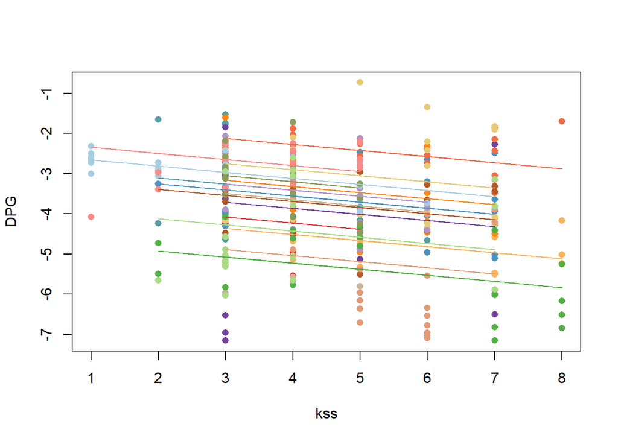

```r
# Plot repeated-measures correlation
plot(rmcorr_KSS_DPG_arvo)
```

```r
KSS_DPG <- lmer(
formula =  kss ~ DPG + Number + Block + (1 |record_id), #+ D1_TAT1k  + mctq_sc4_chronotype + pub_stage + Block
                data = arvo_DPG_KSS)




summary(KSS_DPG)
```

```
Linear mixed model fit by REML. t-tests use Satterthwaite's method [
lmerModLmerTest]
Formula: kss ~ DPG + Number + Block + (1 | record_id)
   Data: arvo_DPG_KSS

REML criterion at convergence: 1219.3

Scaled residuals:
     Min       1Q   Median       3Q      Max
-2.58496 -0.66905 -0.08545  0.57161  3.14403

Random effects:
 Groups    Name        Variance Std.Dev.
 record_id (Intercept) 0.6764   0.8224
 Residual              1.5582   1.2483
Number of obs: 357, groups:  record_id, 17

Fixed effects:
               Estimate Std. Error        df t value Pr(>|t|)
(Intercept)     3.56952    0.39735 135.54978   8.983 1.97e-15 ***
DPG            -0.11734    0.07448 341.02290  -1.575 0.116086
Number          0.13305    0.03445 340.15723   3.862 0.000135 ***
Blockmoderate  -0.58051    0.16193 336.00380  -3.585 0.000387 ***
Blockbright    -0.94804    0.17070 341.14421  -5.554 5.63e-08 ***
---
Signif. codes:  0 '***' 0.001 '**' 0.01 '*' 0.05 '.' 0.1 ' ' 1

Correlation of Fixed Effects:
            (Intr) DPG    Number Blckmd
DPG          0.571
Number      -0.396  0.284
Blockmodert -0.183  0.036  0.010
Blockbright -0.375 -0.318 -0.090  0.462
```

## Association betweeen DPG and KSS data in the evening

```r
# merge datasets
eve_DPG_adj <- eve_DPG %>% mutate(Number=Bin_30m+1)

eve_DPG_KSS <- inner_join(eve_DPG_adj  %>% select (record_id, DPG, Number, minbeforehbt, Block),
                       eve_KSS %>% select(record_id, kss, Number, minbeforehbt, Block), by = c("record_id","Block", "Number"))



# Check structure
str(eve_DPG_KSS)
```

```
tibble [357 × 7] (S3: tbl_df/tbl/data.frame)
 $ record_id     : Factor w/ 22 levels "1","4","6","8",..: 12 12 12 12 12 12 12 12 12 12 ...
 $ DPG           : num [1:357] -3.74 -2.77 -2.18 -2.46 -2.93 ...
 $ Number        : num [1:357] 13 14 15 16 17 18 19 13 14 15 ...
 $ minbeforehbt.x: num [1:357] -105.5 -75.5 -45.5 -15.5 14.5 ...
 $ Block         : Factor w/ 3 levels "dim","moderate",..: 1 1 1 1 1 1 1 2 2 2 ...
 $ kss           : int [1:357] 5 6 6 6 6 6 7 5 5 5 ...
 $ minbeforehbt.y: num [1:357] -90 -60 -30 0 30 60 80 -90 -60 -30 ...
```

```r
eve_DPG_KSS_nobr <- eve_DPG_KSS %>% filter (Block!= "bright")
```

```r
# Compute repeated-measures correlation between PVT and DPG
rmcorr_KSS_DPG_eve <- rmcorr(participant = record_id,
                          measure1 = kss,  # PVT (reaction time)
                          measure2 = DPG,    # DPG (skin temperature drop)
                          dataset = eve_DPG_KSS)

# Print results
print(rmcorr_KSS_DPG_eve)
```

```
Repeated measures correlation

r
0.1210002

degrees of freedom
339

p-value
0.02545528

95% confidence interval
0.01498681 0.2243233
```

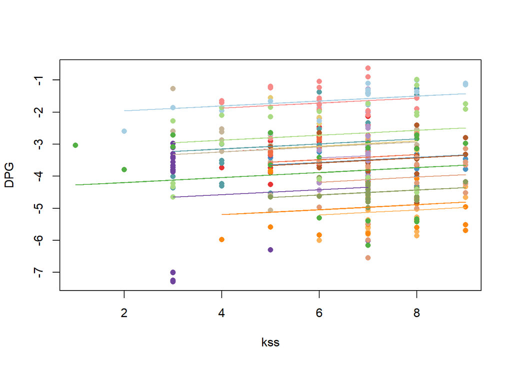

```r
# Plot repeated-measures correlation
plot(rmcorr_KSS_DPG_eve)
```

```r
# compute linear model with DPG as a predictor

KSS_DPG <- lmer(
formula =  kss ~ DPG + Number + Block + (1 |record_id), #+ D1_TAT1k  + mctq_sc4_chronotype + pub_stage + Block
                data = eve_DPG_KSS )


summary(KSS_DPG)
```

```
Linear mixed model fit by REML. t-tests use Satterthwaite's method [
lmerModLmerTest]
Formula: kss ~ DPG + Number + Block + (1 | record_id)
   Data: eve_DPG_KSS

REML criterion at convergence: 1167.1

Scaled residuals:
    Min      1Q  Median      3Q     Max
-4.1773 -0.5907  0.0389  0.6219  2.4088

Random effects:
 Groups    Name        Variance Std.Dev.
 record_id (Intercept) 1.038    1.019
 Residual              1.310    1.145
Number of obs: 357, groups:  record_id, 17

Fixed effects:
               Estimate Std. Error        df t value Pr(>|t|)
(Intercept)     1.19440    0.65967 256.83065   1.811   0.0714 .
DPG             0.07811    0.07428 343.54476   1.052   0.2937
Number          0.34024    0.03077 337.64942  11.056   <2e-16 ***
Blockmoderate   0.22237    0.14845 336.09515   1.498   0.1351
Blockbright    -0.10406    0.15451 339.89330  -0.673   0.5011
---
Signif. codes:  0 '***' 0.001 '**' 0.01 '*' 0.05 '.' 0.1 ' ' 1

Correlation of Fixed Effects:
            (Intr) DPG    Number Blckmd
DPG          0.543
Number      -0.819 -0.176
Blockmodert -0.099  0.025 -0.004
Blockbright -0.259 -0.278  0.049  0.473
```